# Math4432_assignment1

`r par(mfrow = c(3,2)) hist(college$Apps, breaks=150, xlim=c(0,18000), main="Apps") hist(college$Accept, breaks=100, xlim=c(0,15000), main="Accept") hist(college$Enroll, breaks=50, xlim=c(0,4000), main="Enroll") hist(college$Top10perc, breaks=50, xlim=c(0,100), main="Top10perc") hist(college$PhD, breaks=50, xlim=c(0,100), main="PhD") hist(college$Grad.Rate, breaks=50, xlim=c(0,120), main="Grad.Rate")`

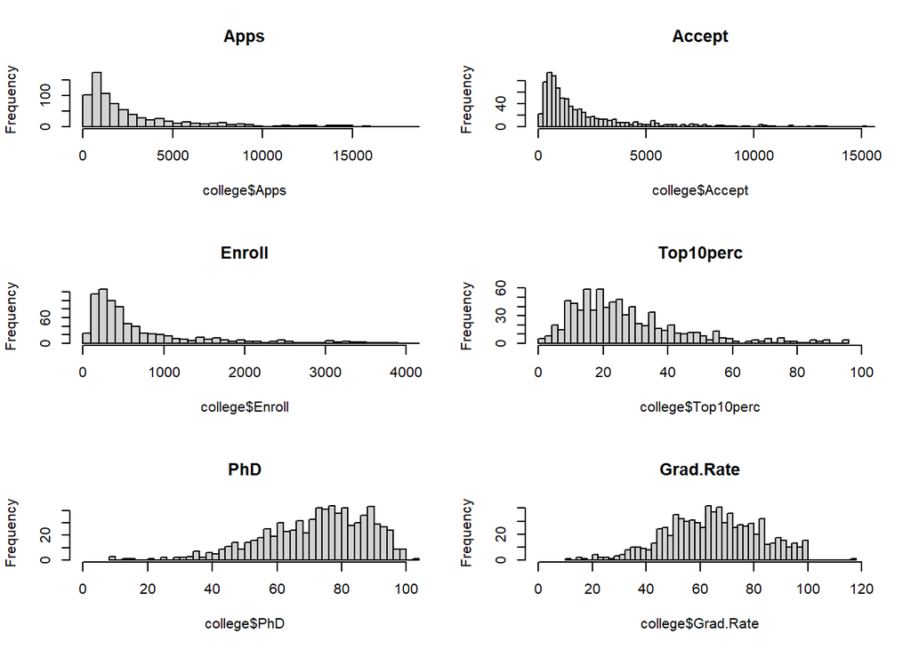

vi. Summary: Private colleges cost more in out-of-state tuition overall. And Elite colleges cost more in it as well. As for elite colleges, they hold more faculties with PhD, which shows stronger academic ability. Also noticed that Elite colleges has more full-time undergraduate students but lower Student/Faculty ratio. Another point is that elite colleges spend more instructional expenditure per student.

`r par(mfrow = c(2,2)) plot(college$Elite, college$PhD, xlab = "Elite", ylab = "PhD") plot(college$Elite, college$F.Undergrad, ylim=c(0,10000), xlab = "Elite", ylab = "F.Undergrad") plot(college$Elite, college$S.F.Ratio, ylim=c(0,30), xlab = "Elite", ylab = "S.F.Ratio") plot(college$Elite, college$Expend, ylim=c(5000,30000), xlab = "Elite", ylab = "Expend")`

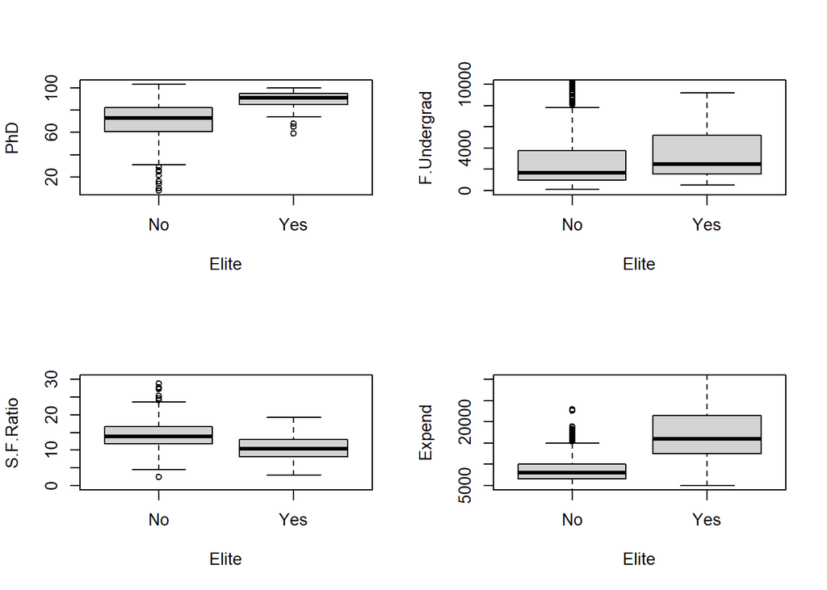

Exercise 2.10: (a) Ans: There are 506 rows and 14 columns.Rows are 506 different house cases in Boston. And columns are 14 index showing conditions of each case.

(14 indexes: refered from resource of dataset CRIM - per capita crime rate by town ZN - proportion of residential land zoned for lots over 25,000 sq.ft. INDUS - proportion of non-retail business acres per town. CHAS - Charles River dummy variable (1 if tract bounds river; 0 otherwise) NOX - nitric oxides concentration (parts per 10 million) RM - average number of rooms per dwelling AGE - proportion of owner-occupied units built prior to 1940 DIS - weighted distances to five Boston employment centres RAD - index of accessibility to radial highways TAX - full-value property-tax rate per $10,000 PTRATIO - pupil-teacher ratio by town B - 1000(Bk - 0.63)^2 where Bk is the proportion of blacks by town LSTAT - % lower status of the population MEDV - Median value of owner-occupied homes in $1000’s)

```r
library(MASS)
Boston
```

|  | crim | zn | indus | chas | nox | rm | age | dis | rad | tax | ptratio | black | lstat | medv |
| --- | --- | --- | --- | --- | --- | --- | --- | --- | --- | --- | --- | --- | --- | --- |
| 1 | 0.00632 | 18.0 | 2.31 | 0 | 0.5380 | 6.575 | 65.2 | 4.0900 | 1 | 296 | 15.3 | 396.90 | 4.98 | 24.0 |
| 2 | 0.02731 | 0.0 | 7.07 | 0 | 0.4690 | 6.421 | 78.9 | 4.9671 | 2 | 242 | 17.8 | 396.90 | 9.14 | 21.6 |
| 3 | 0.02729 | 0.0 | 7.07 | 0 | 0.4690 | 7.185 | 61.1 | 4.9671 | 2 | 242 | 17.8 | 392.83 | 4.03 | 34.7 |
| 4 | 0.03237 | 0.0 | 2.18 | 0 | 0.4580 | 6.998 | 45.8 | 6.0622 | 3 | 222 | 18.7 | 394.63 | 2.94 | 33.4 |
| 5 | 0.06905 | 0.0 | 2.18 | 0 | 0.4580 | 7.147 | 54.2 | 6.0622 | 3 | 222 | 18.7 | 396.90 | 5.33 | 36.2 |
| 6 | 0.02985 | 0.0 | 2.18 | 0 | 0.4580 | 6.430 | 58.7 | 6.0622 | 3 | 222 | 18.7 | 394.12 | 5.21 | 28.7 |
| 7 | 0.08829 | 12.5 | 7.87 | 0 | 0.5240 | 6.012 | 66.6 | 5.5605 | 5 | 311 | 15.2 | 395.60 | 12.43 | 22.9 |
| 8 | 0.14455 | 12.5 | 7.87 | 0 | 0.5240 | 6.172 | 96.1 | 5.9505 | 5 | 311 | 15.2 | 396.90 | 19.15 | 27.1 |
| 9 | 0.21124 | 12.5 | 7.87 | 0 | 0.5240 | 5.631 | 100.0 | 6.0821 | 5 | 311 | 15.2 | 386.63 | 29.93 | 16.5 |
| 10 | 0.17004 | 12.5 | 7.87 | 0 | 0.5240 | 6.004 | 85.9 | 6.5921 | 5 | 311 | 15.2 | 386.71 | 17.10 | 18.9 |

[output cut: 496 more lines]

```r
?Boston
```

```
## starting httpd help server ... done
```

2. We figure out that, the higher air pollution or crime rate, the lower house price. We also notice that high crime cases are mostly located in region where air polltion is high.

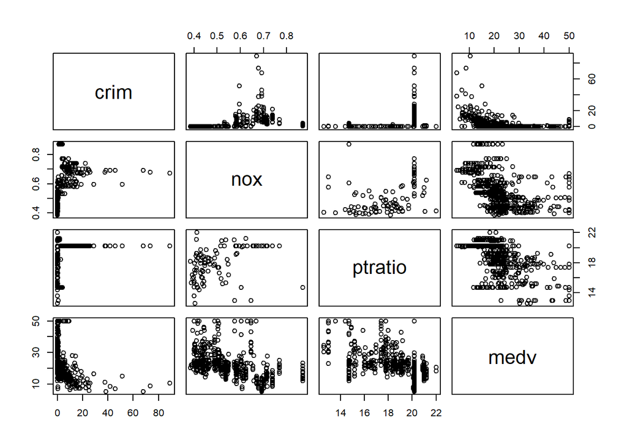

```r
pairs(~crim+nox+ptratio+medv, data = Boston)#we only focus on particular indexes
```